# Explore Bike Share Data

## Data Load & Inspection

### Data Loading

```r
ny = read.csv('new_york_city.csv')
wash = read.csv('washington.csv')
chi = read.csv('chicago.csv')
```

### Data Inspection

```r
head(ny)
```

| X | Start.Time | End.Time | Trip.Duration | Start.Station | End.Station | User.Type | Gender | Birth.Year |
| --- | --- | --- | --- | --- | --- | --- | --- | --- |
| 5688089 | 2017-06-11 14:55:05 | 2017-06-11 15:08:21 | 795 | Suffolk St & Stanton St | W Broadway & Spring St | Subscriber | Male | 1998 |
| 4096714 | 2017-05-11 15:30:11 | 2017-05-11 15:41:43 | 692 | Lexington Ave & E 63 St | 1 Ave & E 78 St | Subscriber | Male | 1981 |
| 2173887 | 2017-03-29 13:26:26 | 2017-03-29 13:48:31 | 1325 | 1 Pl & Clinton St | Henry St & Degraw St | Subscriber | Male | 1987 |
| 3945638 | 2017-05-08 19:47:18 | 2017-05-08 19:59:01 | 703 | Barrow St & Hudson St | W 20 St & 8 Ave | Subscriber | Female | 1986 |
| 6208972 | 2017-06-21 07:49:16 | 2017-06-21 07:54:46 | 329 | 1 Ave & E 44 St | E 53 St & 3 Ave | Subscriber | Male | 1992 |
| 1285652 | 2017-02-22 18:55:24 | 2017-02-22 19:12:03 | 998 | State St & Smith St | Bond St & Fulton St | Subscriber | Male | 1986 |

```r
head(wash)
```

| X | Start.Time | End.Time | Trip.Duration | Start.Station | End.Station | User.Type |
| --- | --- | --- | --- | --- | --- | --- |
| 1621326 | 2017-06-21 08:36:34 | 2017-06-21 08:44:43 | 489.066 | 14th & Belmont St NW | 15th & K St NW | Subscriber |
| 482740 | 2017-03-11 10:40:00 | 2017-03-11 10:46:00 | 402.549 | Yuma St & Tenley Circle NW | Connecticut Ave & Yuma St NW | Subscriber |
| 1330037 | 2017-05-30 01:02:59 | 2017-05-30 01:13:37 | 637.251 | 17th St & Massachusetts Ave NW | 5th & K St NW | Subscriber |
| 665458 | 2017-04-02 07:48:35 | 2017-04-02 08:19:03 | 1827.341 | Constitution Ave & 2nd St NW/DOL | M St & Pennsylvania Ave NW | Customer |
| 1481135 | 2017-06-10 08:36:28 | 2017-06-10 09:02:17 | 1549.427 | Henry Bacon Dr & Lincoln Memorial Circle NW | Maine Ave & 7th St SW | Subscriber |
| 1148202 | 2017-05-14 07:18:18 | 2017-05-14 07:24:56 | 398.000 | 1st & K St SE | Eastern Market Metro / Pennsylvania Ave & 7th St SE | Subscriber |

```r
head(chi)
```

| X | Start.Time | End.Time | Trip.Duration | Start.Station | End.Station | User.Type | Gender | Birth.Year |
| --- | --- | --- | --- | --- | --- | --- | --- | --- |
| 1423854 | 2017-06-23 15:09:32 | 2017-06-23 15:14:53 | 321 | Wood St & Hubbard St | Damen Ave & Chicago Ave | Subscriber | Male | 1992 |
| 955915 | 2017-05-25 18:19:03 | 2017-05-25 18:45:53 | 1610 | Theater on the Lake | Sheffield Ave & Waveland Ave | Subscriber | Female | 1992 |
| 9031 | 2017-01-04 08:27:49 | 2017-01-04 08:34:45 | 416 | May St & Taylor St | Wood St & Taylor St | Subscriber | Male | 1981 |
| 304487 | 2017-03-06 13:49:38 | 2017-03-06 13:55:28 | 350 | Christiana Ave & Lawrence Ave | St. Louis Ave & Balmoral Ave | Subscriber | Male | 1986 |
| 45207 | 2017-01-17 14:53:07 | 2017-01-17 15:02:01 | 534 | Clark St & Randolph St | Desplaines St & Jackson Blvd | Subscriber | Male | 1975 |
| 1473887 | 2017-06-26 09:01:20 | 2017-06-26 09:11:06 | 586 | Clinton St & Washington Blvd | Canal St & Taylor St | Subscriber | Male | 1990 |

### Structural Analysis

```r
str(ny)
```

```
'data.frame':	54770 obs. of  9 variables:
 $ X            : int  5688089 4096714 2173887 3945638 6208972 1285652 1675753 1692245 2271331 1558339 ...
 $ Start.Time   : Factor w/ 54568 levels "2017-01-01 00:17:01",..: 45448 32799 17316 31589 49688 10220 13390 13509 18111 12449 ...
 $ End.Time     : Factor w/ 54562 levels "201","2017-01-01 00:30:56",..: 45432 32783 17295 31567 49668 10204 13364 13505 18092 12422 ...
 $ Trip.Duration: int  795 692 1325 703 329 998 478 4038 5132 309 ...
 $ Start.Station: Factor w/ 636 levels "","1 Ave & E 16 St",..: 522 406 10 93 5 521 325 309 151 245 ...
 $ End.Station  : Factor w/ 638 levels "","1 Ave & E 16 St",..: 613 8 362 558 269 107 389 110 151 243 ...
 $ User.Type    : Factor w/ 3 levels "","Customer",..: 3 3 3 3 3 3 3 3 2 3 ...
 $ Gender       : Factor w/ 3 levels "","Female","Male": 3 3 3 2 3 3 3 3 1 3 ...
 $ Birth.Year   : num  1998 1981 1987 1986 1992 ...
```

```r
str(wash)
```

```
'data.frame':	89051 obs. of  7 variables:
 $ X            : int  1621326 482740 1330037 665458 1481135 1148202 1594275 1601832 574182 327058 ...
 $ Start.Time   : Factor w/ 81223 levels "","2017-01-01 00:11:00",..: 74753 19510 59964 26708 67716 50891 73381 73775 23142 13333 ...
 $ End.Time     : Factor w/ 81217 levels "","2017-01-01 00:14:00",..: 74744 19473 59981 26732 67753 50918 73397 73775 23114 13350 ...
 $ Trip.Duration: num  489 403 637 1827 1549 ...
 $ Start.Station: Factor w/ 478 levels "","10th & E St NW",..: 27 478 66 221 278 84 368 82 71 60 ...
 $ End.Station  : Factor w/ 479 levels "","10th & E St NW",..: 47 219 144 312 315 239 162 376 51 308 ...
 $ User.Type    : Factor w/ 3 levels "","Customer",..: 3 3 3 2 3 3 3 3 3 3 ...
```

```r
str(chi)
```

```
'data.frame':	8630 obs. of  9 variables:
 $ X            : int  1423854 955915 9031 304487 45207 1473887 961916 65924 606841 135470 ...
 $ Start.Time   : Factor w/ 8624 levels "2017-01-01 00:40:14",..: 7876 5303 73 1721 267 8173 5347 368 3376 795 ...
 $ End.Time     : Factor w/ 8625 levels "2017-01-01 00:46:32",..: 7876 5303 73 1722 267 8173 5346 368 3376 796 ...
 $ Trip.Duration: int  321 1610 416 350 534 586 281 723 689 493 ...
 $ Start.Station: Factor w/ 472 levels "2112 W Peterson Ave",..: 468 424 291 80 103 119 22 255 374 420 ...
 $ End.Station  : Factor w/ 471 levels "","2112 W Peterson Ave",..: 132 381 469 409 151 70 467 251 200 118 ...
 $ User.Type    : Factor w/ 3 levels "","Customer",..: 3 3 3 3 3 3 3 2 3 3 ...
 $ Gender       : Factor w/ 3 levels "","Female","Male": 3 2 3 3 3 3 2 1 3 3 ...
 $ Birth.Year   : num  1992 1992 1981 1986 1975 ...
```

#### Structure Analysis Review:

1) NY has 54,770 rows with 9 columns. Start and End times are currently "Factor" typewhich need to be converted to datetime. There also appear to be "" values in multiple columns to be aware of if those columns are necessary for analysis and answering the questions. These will be treated as missing values and not a separate category.

2) Ny has a stray value of "201" under End.Time which could make parsing to datetime prone to error. End.Time is not needed for the related questions and will be removed from the working dataset, along with a few other columns, prior to analysis and visualization.

3) Wash has 89,051 rows but only 7 columns (missing Gender and Birth Year). These will also be dropped in the final merged dataset and are overall not necessary for the three questions being asked, but were pointed out for clarity.

4) Trip duration for NY and Chi are int, but Wash duration is num. These will need to be a a consistent num type for precision and better percentile/quantile statistical functions.

5) Chi only 8,630 rows but similar issues to NY.

### Summary Analysis

```r
summary(ny)
```

```
       X                         Start.Time                   End.Time
 Min.   :     47   2017-05-11 18:26:10:    3   2017-01-03 08:54:10:    2
 1st Qu.:1712425   2017-01-04 13:58:24:    2   2017-01-04 17:21:55:    2
 Median :3418634   2017-01-09 09:36:01:    2   2017-01-05 17:25:17:    2
 Mean   :3415873   2017-01-21 15:36:56:    2   2017-01-12 08:34:01:    2
 3rd Qu.:5123382   2017-01-21 17:49:59:    2   2017-01-12 09:41:54:    2
 Max.   :6816152   2017-01-21 20:08:29:    2   2017-01-12 20:34:42:    2
                   (Other)            :54757   (Other)            :54758
 Trip.Duration                     Start.Station
 Min.   :     61.0   Pershing Square North:  592
 1st Qu.:    368.0   W 21 St & 6 Ave      :  385
 Median :    610.0   Broadway & E 22 St   :  383
 Mean   :    903.6   E 17 St & Broadway   :  380
 3rd Qu.:   1051.0   West St & Chambers St:  364
 Max.   :1088634.0   W 20 St & 11 Ave     :  329
 NA's   :1           (Other)              :52337
                End.Station         User.Type        Gender        Birth.Year
 Pershing Square North:  556             :  119         : 5410   Min.   :1885
 E 17 St & Broadway   :  445   Customer  : 5558   Female:12159   1st Qu.:1970
 Broadway & E 22 St   :  427   Subscriber:49093   Male  :37201   Median :1981
 W 21 St & 6 Ave      :  365                                     Mean   :1978
 W 20 St & 11 Ave     :  344                                     3rd Qu.:1988
 W 38 St & 8 Ave      :  338                                     Max.   :2001
 (Other)              :52295                                     NA's   :5218
```

```r
summary(wash)
```

```
       X                         Start.Time                   End.Time
 Min.   :      7   2017-02-19 12:19:00:    6   2017-03-09 17:54:00:    7
 1st Qu.: 434587   2017-02-20 11:35:00:    6   2017-03-28 18:11:00:    7
 Median : 872858   2017-02-24 17:46:00:    6   2017-01-13 17:48:00:    6
 Mean   : 873881   2017-03-01 08:20:00:    6   2017-01-31 08:49:00:    6
 3rd Qu.:1313305   2017-03-02 08:39:00:    6   2017-02-13 18:09:00:    6
 Max.   :1751392   2017-03-09 17:31:00:    6   2017-02-20 11:38:00:    6
                   (Other)            :89015   (Other)            :89013
 Trip.Duration                                   Start.Station
 Min.   :    60.3   Columbus Circle / Union Station     : 1700
 1st Qu.:   410.9   Lincoln Memorial                    : 1546
 Median :   707.0   Jefferson Dr & 14th St SW           : 1488
 Mean   :  1234.0   Massachusetts Ave & Dupont Circle NW: 1219
 3rd Qu.:  1233.2   Jefferson Memorial                  : 1068
 Max.   :904591.4   15th & P St NW                      : 1040
 NA's   :1          (Other)                             :80990
                                                End.Station
 Columbus Circle / Union Station                      : 1767
 Jefferson Dr & 14th St SW                            : 1603
 Lincoln Memorial                                     : 1514
 Massachusetts Ave & Dupont Circle NW                 : 1344
 Smithsonian-National Mall / Jefferson Dr & 12th St SW: 1103
 15th & P St NW                                       : 1077
 (Other)                                              :80643
      User.Type
           :    1
 Customer  :23450
 Subscriber:65600
```

```r
summary(chi)
```

```
       X                         Start.Time                  End.Time
 Min.   :     36   2017-01-24 07:40:32:   2   2017-04-16 13:16:52:   2
 1st Qu.: 386722   2017-04-22 13:16:25:   2   2017-04-26 16:29:26:   2
 Median : 773554   2017-05-27 15:17:50:   2   2017-05-21 16:20:56:   2
 Mean   : 776721   2017-06-10 13:29:41:   2   2017-05-27 09:58:21:   2
 3rd Qu.:1171266   2017-06-20 17:05:11:   2   2017-06-25 14:51:35:   2
 Max.   :1551248   2017-06-21 13:18:52:   2   2017-01-01 00:46:32:   1
                   (Other)            :8618   (Other)            :8619
 Trip.Duration                          Start.Station
 Min.   :   60.0   Streeter Dr & Grand Ave     : 210
 1st Qu.:  394.2   Lake Shore Dr & Monroe St   : 140
 Median :  670.0   Clinton St & Washington Blvd: 120
 Mean   :  937.2   Clinton St & Madison St     : 102
 3rd Qu.: 1119.0   Canal St & Adams St         : 101
 Max.   :85408.0   Michigan Ave & Oak St       :  98
                   (Other)                     :7859
                       End.Station        User.Type       Gender
 Streeter Dr & Grand Ave     : 233             :   1         :1748
 Clinton St & Madison St     : 145   Customer  :1746   Female:1723
 Theater on the Lake         : 131   Subscriber:6883   Male  :5159
 Lake Shore Dr & Monroe St   : 115
 Clinton St & Washington Blvd: 109
 Lake Shore Dr & North Blvd  : 102
 (Other)                     :7795
   Birth.Year
 Min.   :1899
 1st Qu.:1975
 Median :1984
 Mean   :1981
 3rd Qu.:1989
 Max.   :2002
 NA's   :1747
```

#### Summary Analysis Review

2) NA's are identified for NY and Wash for 1 trip duration in each city. These will be imputed to the median to provide complete, logical values. Because there are going to be thousands and thousands of trips on the lower-end, the median value should be safer in this particular project in case of a few relatively high values pulling the average up.

3) There are also illogical birth years listed (e.g. 1885 and 1899, making people over 100 years old when this data would have been recorded). As with previous items, birth year data is unnecessary to answer or analyze the questions presented. These fields will be dropped when creating the working tables.

### Categorical Analysis

```r
colSums(is.na(ny))
```

**X**

0

**Start.Time**

0

**End.Time**

0

**Trip.Duration**

1

**Start.Station**

0

**End.Station**

0

**User.Type**

0

**Gender**

0

**Birth.Year**

5218

```r
colSums(is.na(wash))
```

**X**

0

**Start.Time**

0

**End.Time**

0

**Trip.Duration**

1

**Start.Station**

0

**End.Station**

0

**User.Type**

0

```r
colSums(is.na(chi))
```

**X**

0

**Start.Time**

0

**End.Time**

0

**Trip.Duration**

0

**Start.Station**

0

**End.Station**

0

**User.Type**

0

**Gender**

0

**Birth.Year**

1747

```r
sum(duplicated(ny))
```

0

```r
sum(duplicated(wash))
```

0

```r
sum(duplicated(chi))
```

0

```r
sum(ny$User.Type == "")
```

119

```r
sum(wash$User.Type == "")
```

1

```r
sum(chi$User.Type == "")
```

1

#### Categorical Analysis:

1) Multiple missing values for Birth Year for both NY and Chi but, as stated previously, these are not critical to the three questions being considered.

2) Also identified earlier, NY and Wash are both missing a single trip duration. With the nature of the time data and overall trips, it should be permissible to use the median value to ensure there are no missing values from the trip duration field as that is a crucial field for question 3.

3) There are no duplicated rows which reduces the steps needed for cleaning and merging.

## Data Cleaning & Preparation

```r
# ny time conversion, add city column for merging clarity,
# update missing User.Type to 'Unknown', duration
# conversion to num, and replace missing Trip.Duration
# value with median

library(lubridate)

ny_working <- ny[,c('Start.Time', 'Trip.Duration', 'User.Type')]

ny_working$Start.Time <- ymd_hms(ny_working$Start.Time)
ny_working$Start.Hour <- hour(ny_working$Start.Time)
ny_working$Start.Minute <- minute(ny_working$Start.Time)

ny_working$City <- 'New York City'

ny_working$User.Type <- as.character(ny_working$User.Type)
ny_working$User.Type <- trimws(ny_working$User.Type, c("both"))
ny_working$User.Type[ny_working$User.Type == ""] <- "Unknown"

ny_working$Trip.Duration <- as.numeric(ny_working$Trip.Duration)
ny_working$Trip.Duration[is.na(ny_working$Trip.Duration)] <- median(ny_working$Trip.Duration, na.rm = TRUE)
```

```r
# wash time conversion, add city column for merging clarity,
# and update missing User.Type to 'Unknown', and
# replace missing Trip.Duration value with median

wash_working <- wash[,c('Start.Time', 'Trip.Duration', 'User.Type')]

wash_working$Start.Time <- ymd_hms(wash_working$Start.Time)
wash_working$Start.Hour <- hour(wash_working$Start.Time)
wash_working$Start.Minute <- minute(wash_working$Start.Time)

wash_working$City <- 'Washington DC'

wash_working$User.Type <- as.character(wash_working$User.Type)
wash_working$User.Type <- trimws(wash_working$User.Type, c("both"))
wash_working$User.Type[wash_working$User.Type == ""] <- "Unknown"

wash_working$Trip.Duration[is.na(wash_working$Trip.Duration)] <- median(wash_working$Trip.Duration, na.rm = TRUE)
```

```r
# chi time conversion, add city column for merging clarity,
# and update missing User.Type to 'Unknown',  and duration
# conversion to num

chi_working <- chi[,c('Start.Time', 'Trip.Duration', 'User.Type')]

chi_working$Start.Time <- ymd_hms(chi_working$Start.Time)
chi_working$Start.Hour <- hour(chi_working$Start.Time)
chi_working$Start.Minute <- minute(chi_working$Start.Time)

chi_working$City <- 'Chicago'

chi_working$User.Type <- as.character(chi_working$User.Type)
chi_working$User.Type <- trimws(chi_working$User.Type, c("both"))
chi_working$User.Type[chi_working$User.Type == ""] <- "Unknown"

chi_working$Trip.Duration <- as.numeric(chi_working$Trip.Duration)
```

```r
# cap Ny Trip.Duration to 99th percentile value
quan_99 <- quantile(ny_working$Trip.Duration, probs = .99, na.rm = TRUE)

ny_working_precap <- ny_working

ny_working$Trip.Duration <- pmin(ny_working$Trip.Duration, quan_99)
```

```r
# cap Wash Trip.Duration to 99th percentile value
quan_99 <- quantile(wash_working$Trip.Duration, probs = .99, na.rm = TRUE)

wash_working_precap <- wash_working

wash_working$Trip.Duration <- pmin(wash_working$Trip.Duration, quan_99)
```

```r
# cap Chi Trip.Duration to 99th percentile value
quan_99 <- quantile(chi_working$Trip.Duration, probs = .99, na.rm = TRUE)

chi_working_precap <- chi_working

chi_working$Trip.Duration <- pmin(chi_working$Trip.Duration, quan_99)
```

```r
head(ny_working)
```

| Start.Time | Trip.Duration | User.Type | Start.Hour | Start.Minute | City |
| --- | --- | --- | --- | --- | --- |
| 2017-06-11 14:55:05 | 795 | Subscriber | 14 | 55 | New York City |
| 2017-05-11 15:30:11 | 692 | Subscriber | 15 | 30 | New York City |
| 2017-03-29 13:26:26 | 1325 | Subscriber | 13 | 26 | New York City |
| 2017-05-08 19:47:18 | 703 | Subscriber | 19 | 47 | New York City |
| 2017-06-21 07:49:16 | 329 | Subscriber | 7 | 49 | New York City |
| 2017-02-22 18:55:24 | 998 | Subscriber | 18 | 55 | New York City |

```r
summary(ny_working)
```

```
   Start.Time                  Trip.Duration     User.Type
 Min.   :2017-01-01 00:17:01   Min.   :  61.0   Length:54770
 1st Qu.:2017-03-07 18:47:48   1st Qu.: 368.0   Class :character
 Median :2017-04-28 12:04:49   Median : 610.0   Mode  :character
 Mean   :2017-04-19 05:14:05   Mean   : 798.4
 3rd Qu.:2017-06-01 16:46:03   3rd Qu.:1051.0
 Max.   :2017-06-30 23:52:44   Max.   :3407.0
   Start.Hour     Start.Minute      City
 Min.   : 0.00   Min.   : 0.0   Length:54770
 1st Qu.:10.00   1st Qu.:15.0   Class :character
 Median :15.00   Median :30.0   Mode  :character
 Mean   :13.95   Mean   :29.5
 3rd Qu.:18.00   3rd Qu.:44.0
 Max.   :23.00   Max.   :59.0
```

```r
head(wash_working)
```

| Start.Time | Trip.Duration | User.Type | Start.Hour | Start.Minute | City |
| --- | --- | --- | --- | --- | --- |
| 2017-06-21 08:36:34 | 489.066 | Subscriber | 8 | 36 | Washington DC |
| 2017-03-11 10:40:00 | 402.549 | Subscriber | 10 | 40 | Washington DC |
| 2017-05-30 01:02:59 | 637.251 | Subscriber | 1 | 2 | Washington DC |
| 2017-04-02 07:48:35 | 1827.341 | Customer | 7 | 48 | Washington DC |
| 2017-06-10 08:36:28 | 1549.427 | Subscriber | 8 | 36 | Washington DC |
| 2017-05-14 07:18:18 | 398.000 | Subscriber | 7 | 18 | Washington DC |

```r
summary(wash_working)
```

```
   Start.Time                  Trip.Duration      User.Type
 Min.   :2017-01-01 00:11:00   Min.   :  60.27   Length:89051
 1st Qu.:2017-03-05 18:34:00   1st Qu.: 410.89   Class :character
 Median :2017-04-18 07:44:18   Median : 706.99   Mode  :character
 Mean   :2017-04-15 00:41:22   Mean   :1112.99
 3rd Qu.:2017-05-28 09:41:00   3rd Qu.:1233.21
 Max.   :2017-06-30 12:55:16   Max.   :8604.09
 NA's   :1
   Start.Hour      Start.Minute       City
 Min.   : 0.000   Min.   : 0.00   Length:89051
 1st Qu.: 6.000   1st Qu.:14.00   Class :character
 Median : 8.000   Median :29.00   Mode  :character
 Mean   : 9.217   Mean   :29.43
 3rd Qu.:12.000   3rd Qu.:44.00
 Max.   :23.000   Max.   :59.00
 NA's   :1        NA's   :1
```

```r
head(chi_working)
```

| Start.Time | Trip.Duration | User.Type | Start.Hour | Start.Minute | City |
| --- | --- | --- | --- | --- | --- |
| 2017-06-23 15:09:32 | 321 | Subscriber | 15 | 9 | Chicago |
| 2017-05-25 18:19:03 | 1610 | Subscriber | 18 | 19 | Chicago |
| 2017-01-04 08:27:49 | 416 | Subscriber | 8 | 27 | Chicago |
| 2017-03-06 13:49:38 | 350 | Subscriber | 13 | 49 | Chicago |
| 2017-01-17 14:53:07 | 534 | Subscriber | 14 | 53 | Chicago |
| 2017-06-26 09:01:20 | 586 | Subscriber | 9 | 1 | Chicago |

```r
summary(chi_working)
```

```
   Start.Time                  Trip.Duration     User.Type
 Min.   :2017-01-01 00:40:14   Min.   :  60.0   Length:8630
 1st Qu.:2017-03-23 15:23:37   1st Qu.: 394.2   Class :character
 Median :2017-05-09 18:50:53   Median : 670.0   Mode  :character
 Mean   :2017-04-27 10:12:04   Mean   : 885.5
 3rd Qu.:2017-06-08 11:08:41   3rd Qu.:1119.0
 Max.   :2017-06-30 23:10:48   Max.   :5105.0
   Start.Hour     Start.Minute       City
 Min.   : 0.00   Min.   : 0.00   Length:8630
 1st Qu.:10.00   1st Qu.:14.00   Class :character
 Median :14.00   Median :29.00   Mode  :character
 Mean   :13.65   Mean   :29.19
 3rd Qu.:17.00   3rd Qu.:44.00
 Max.   :23.00   Max.   :59.00
```

#### Cleaning Steps Before Merging

For each city, I trimmed each down to a table containing Start.Time, Trip.Duration, User.Type, and a new City field.

I converted Start.Time from Factor to POSIXct and retrieved the hour/minute values for time-of-day analysis.

I standardized Trip.Duration to numeric (seconds) and applied a 99th percentile cap to deal with extreme outliers.

Finally, I aligned column names and classes across cities to ensure row merging is successful for cross-city comparisons while dropping unused columns (e.g., End.Time, Gender, Birth.Year) from the working tables but leaving them in the raw data.

#### Table Joins

```r
combined_cities <- rbind(ny_working, wash_working, chi_working)
```

```r
nrow(combined_cities)
```

152451

```r
str(combined_cities)
```

```
'data.frame':	152451 obs. of  6 variables:
 $ Start.Time   : POSIXct, format: "2017-06-11 14:55:05" "2017-05-11 15:30:11" ...
 $ Trip.Duration: num  795 692 1325 703 329 ...
 $ User.Type    : chr  "Subscriber" "Subscriber" "Subscriber" "Subscriber" ...
 $ Start.Hour   : int  14 15 13 19 7 18 16 7 8 23 ...
 $ Start.Minute : int  55 30 26 47 49 55 22 42 2 1 ...
 $ City         : chr  "New York City" "New York City" "New York City" "New York City" ...
```

## Analysis and testing

### Question 1

*Does the bikeshare service have more customers or subscribers using the service?*

$H_0$: Among rides, the proportion of Subscribers equals the proportion of Customers both overall and in each city.

$H_1$: The proportions are not equal and Subscribers have a greater proportion than Customers.

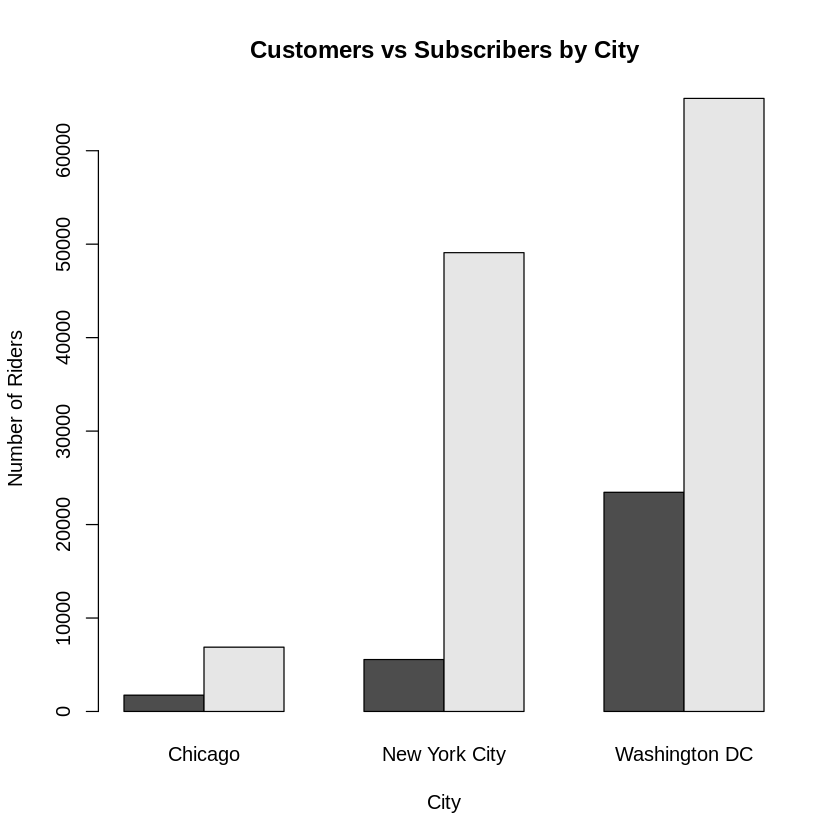

```r
# Filter to just city types to remove "Uknown"
combined_cities_types <- subset(combined_cities, User.Type %in% c('Customer', 'Subscriber'))

# Two way table with rows as user type and columns as cities
city_count <- table(combined_cities_types$User.Type, combined_cities_types$City)

barplot(city_count,
        beside=TRUE,
        args.legend = list(x = "topright", bty = "n"),
        main = "Customers vs Subscribers by City",
        xlab = "City",
        ylab = "Number of Riders")
```

```r
# Numeric verification
overall_count <- table(combined_cities_types$User.Type)
overall_percent <- round(prop.table(overall_count) * 100, 1)

city_percent <- round(prop.table(city_count, margin = 2) * 100, 1)

cat("Overall count:\n");          print(overall_count)
cat("\nOverall percentages (%):\n"); print(overall_percent)

cat("\nPer city counts:\n");         print(city_count)
cat("\nPer city percentages (%):\n"); print(city_percent)

# Pearson test to determine if user type distribution differs by city
chisq_testing <- chisq.test(city_count)
chisq_testing
```

```
Overall count:

  Customer Subscriber
     30754     121576

Overall percentages (%):

  Customer Subscriber
      20.2       79.8

Per city counts:

             Chicago New York City Washington DC
  Customer      1746          5558         23450
  Subscriber    6883         49093         65600

Per city percentages (%):

             Chicago New York City Washington DC
  Customer      20.2          10.2          26.3
  Subscriber    79.8          89.8          73.7
```

```
	Pearson's Chi-squared test

data:  city_count
X-squared = 5491.2, df = 2, p-value < 2.2e-16
```

**Q1 Summary**  
After visual and numeric analysis, it is clear the null hypothesis is rejected. Subscribers have a far greater portion of bikeshare usage. Subscribers make up 79.8% of all rides compared to just 20.2% for regular customers. To confirm if there was any difference in the cities, I completed a chi-square test to confirm the mix of subscribers and customers does differ by city (p-value < .001).

Final city percentage differences:  
Chicago: **79.8% subscribers vs 20.2% customers**  
New York City: **89.8% subscribers vs 10.2% customers**  
Washington DC: **73.7% subscribers vs 26.3% customers**

### Question 2

*What is the most common time (hour, day, month) to start a bikesharing ride?*

$H_0$: Ride start times are evenly distributed across the 24 hours of the day.

$H_1$: Ride start times are not evenly distributed across hours and at least one hour is more common than others.

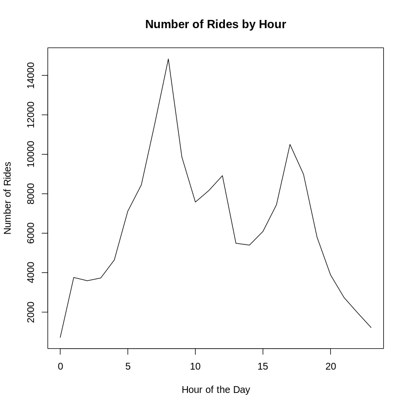

```r
# Plot by hours
count_hours <- table(combined_cities$Start.Hour)

x_axis <- as.numeric(names(count_hours))
y_axis <- as.numeric(count_hours)

plot(x_axis, y_axis, type = "l",
    main = "Number of Rides by Hour",
    xlab = "Hour of the Day",
    ylab = "Number of Rides")
```

```r
# Hourly numeric verifications
cat("Maximum Hours"); which.max(count_hours)
chisq.test(count_hours, p=rep(1/24, 24))
```

```
Maximum Hours
```

**8:** 9

```
	Chi-squared test for given probabilities

data:  count_hours
X-squared = 43419, df = 23, p-value < 2.2e-16
```

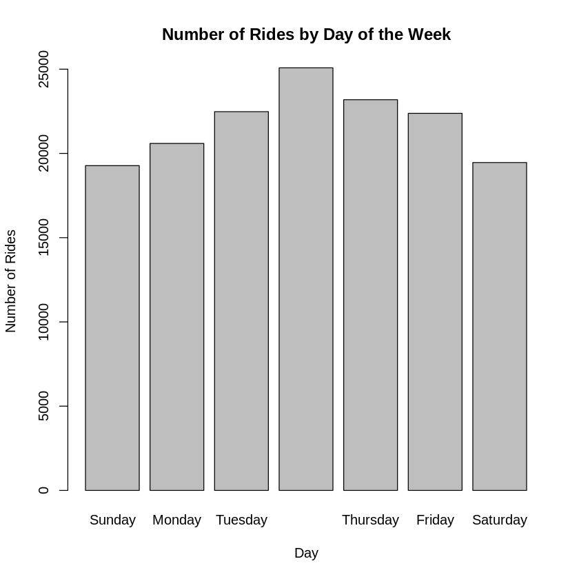

```r
# Plot by weekday
weekday_names = c("Sunday", "Monday", "Tuesday", "Wednesday", "Thursday", "Friday", "Saturday")
weekdays_factor = factor(weekdays(combined_cities$Start.Time), levels = weekday_names)

barplot(table(weekdays_factor),
       main = "Number of Rides by Day of the Week",
       xlab = "Day",
       ylab = "Number of Rides")
```

```r
# Weekday numeric verifications
cat("Most popular day");
weekday_counts <- table(weekdays_factor); names(weekday_counts)[which.max(weekday_counts)]

chisq.test(weekday_counts, p = rep(1/7, 7))
```

```
Most popular day
```

'Wednesday'

```
	Chi-squared test for given probabilities

data:  weekday_counts
X-squared = 1230.2, df = 6, p-value < 2.2e-16
```

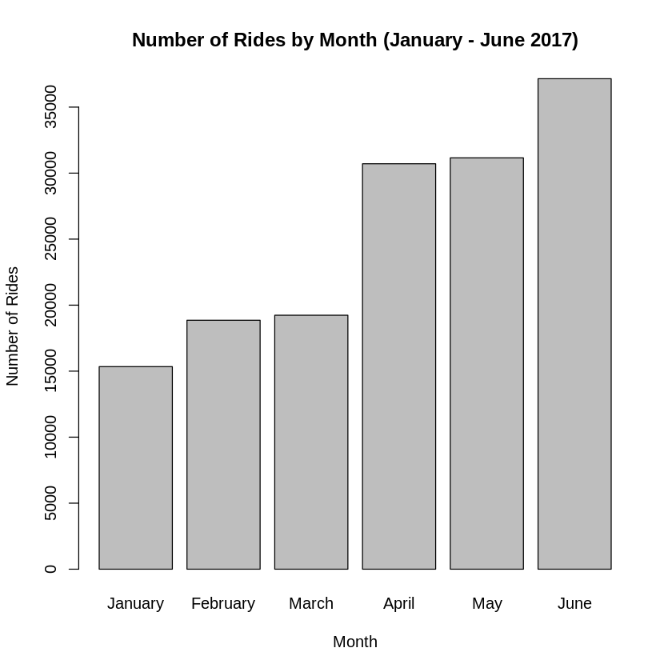

```r
# Plot by first 6 months of the year
month_names = c("January", "February", "March", "April", "May", "June")
months_factor <- factor(months(combined_cities$Start.Time), levels = month_names)

barplot(table(months_factor),
       main = "Number of Rides by Month (January - June 2017)",
       xlab = "Month",
       ylab = "Number of Rides")
```

```r
# Monthly numeric verifications
cat("Most popular month");
month_counts <- table(months_factor); names(month_counts)[which.max(month_counts)]

chisq.test(month_counts, p = rep(1/6, 6))
```

```
Most popular month
```

'June'

```
	Chi-squared test for given probabilities

data:  month_counts
X-squared = 15011, df = 5, p-value < 2.2e-16
```

**Question 2 summary**  
Rides are not evenly distributed throughout the day, week or month. In terms of each day/hours of the day, rides peak in the morning (approximately 8–9 AM) which is logical with morning commutes in major cities and begin to drop off as the cities reach nightfall and into the late night. Weekday activity hits its peak in the middle of the week with Wednesday being the most popular. And, in looking at the first six months of the year for verification, the outcomes are also completely logical as rides being to rise going into summer with the biggest peak in June.

The chi-square tests show a strong rejection of the null hypothesis across all hourly/daily/monthly spectrums with very small p-values.

### Question 3

*What is the average amount of time people spend using the bikesharing service?*

$H_0$: The average trip duration is the same across Chicago, New York City, and Washington DC

$H_1$: At least one city’s average trip duration is different.

```r
# City averages in minutes
average_minute_per_city <- tapply(combined_cities$Trip.Duration,
                                  combined_cities$City,
                                 function(x) mean(x, na.rm = TRUE) / 60)

round(average_minute_per_city)

# City totals in hours
hours_per_city <- tapply(combined_cities$Trip.Duration,
                        combined_cities$City,
                        function(x) sum(x, na.rm = TRUE) / 3600)
round(hours_per_city, 1)

totals_table = table(combined_cities$City)
```

**Chicago**

15

**New York City**

13

**Washington DC**

19

**Chicago**

2122.8

**New York City**

12147

**Washington DC**

27531.4

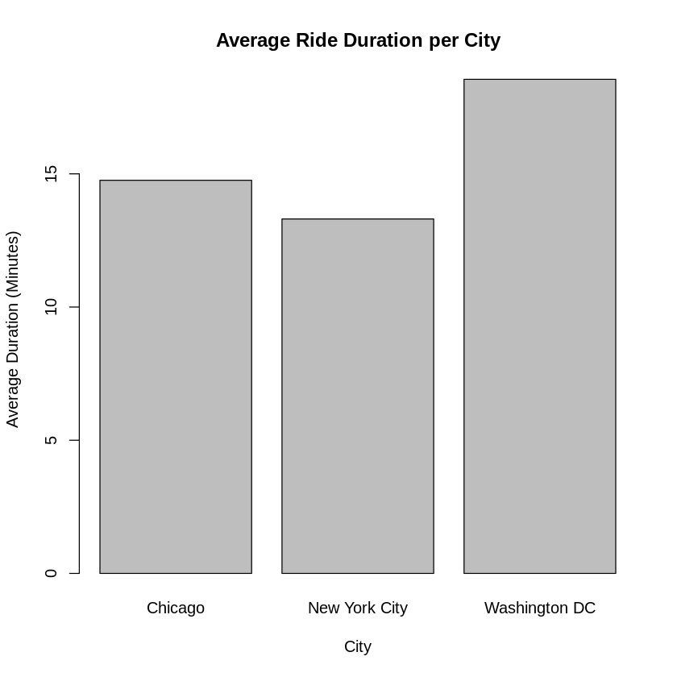

```r
# Visualization for minutes
barplot(average_minute_per_city,
       main = "Average Ride Duration per City",
       xlab = "City",
       ylab = "Average Duration (Minutes)")
```

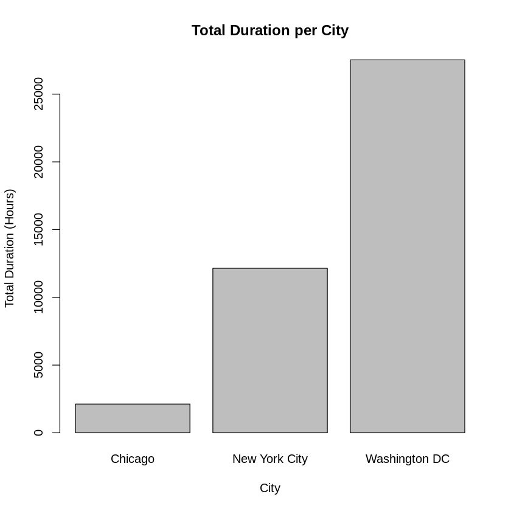

```r
barplot(hours_per_city,
       main = "Total Duration per City",
       xlab = "City",
       ylab = "Total Duration (Hours)")
```

```r
# Numeric verification using Pairwise Wilcoxon testing to check against city group pairings for duration
# differences to use ranking to account for skews between large gaps in users in some cities &
# ANOVA method to verify if average ride times are the same or if at least one city is different

cities_data <- subset(combined_cities, is.finite(Trip.Duration) & !is.na(City))
cities_data$City <- factor(cities_data$City)

pairwise.wilcox.test(cities_data$Trip.Duration, cities_data$City, p.adjust.method = "BH")

anova_test <- aov(log(Trip.Duration) ~ City, data = cities_data)
summary(anova_test)
```

```
	Pairwise comparisons using Wilcoxon rank sum test

data:  cities_data$Trip.Duration and cities_data$City

              Chicago New York City
New York City 2.5e-15 -
Washington DC < 2e-16 < 2e-16

P value adjustment method: BH
```

```
                Df Sum Sq Mean Sq F value Pr(>F)
City             2   1169   584.6   894.7 <2e-16 ***
Residuals   152448  99603     0.7
---
Signif. codes:  0 ‘***’ 0.001 ‘**’ 0.01 ‘*’ 0.05 ‘.’ 0.1 ‘ ’ 1
```

**Question 3 Summary**  
Again, we must reject the null hypothesis for question 3 as the average ride length is different for each city. Average ride for Washington DC is approximately 19 minutes, Chicago is approximately 15 minutes, and New York City is approximately 13 min.

Pairwise Wilcoxon testing was used to confirm that all city pairs differ (p-value < 0.001) while being robust to skews. The ANOVA test, using log durations to adjust for the tail of long ride durations (logical, as the bikes are meant for short rentals to nearby locations), also helps to verify that we reject the null hypothesis (i.e., p-value < .001). The chances that the city averages being so far apart and based on "luck" are effectively 0.

DC, by far, contributed the most hours overall for rideshares even adjusting for the skew on total riders.

**Limitations**:  
There were limitations with the datasets available:  
1) Washington DC data was missing all Gender and Birth Year information, making those fields effectively unusable for potential questions.  
2) Extreme and potentially incorrect outliers resulted in capping which reduces totals.  
3) Analysis could only consist of January through June data.